# Modeling Dengue Transmission via POMP

4/25/2018

# Introduction

## Motivation and Background

The dengue virus is a viral infection primarily transmitted between people via mosquitoes (in particular the Aedes aegypti) characterized by its ability to clinically manifest as a flu-like illness, and in more severe cases into, dengue hemorrhagic fever/ dengue shock syndrome (DHF/DSS). In severe cases, dengue infections require hospitalization and can be fatal. The World Health Organization estimates that around 500,000 cases of dengue require hospitalizations. Additionally, the case fatality rate ranges from 10-15% in certain countries and <1% in others (Gubler 2002).

According to Gubler (1998) historical evidence suggests that there were relatively infrequent and isolated outbreaks of dengue fever (or a very similar disease) throughout time in places such as China, the French West Indies, and even in Philadelphia. However, the ecologic changes in Southeast asia caused by the onset and aftermath of WWII has created an environment for dengue to thrive increasing the frequency of dengue epidemic within the region since the post World War II times. Within Asia, Dengue has spread from Southeast Asian countries to neighboring countries such as India, Sri Lanka, the Maldives, and China as well as many Pacific islands. Growth has not been limited to Asia as dengue has spread globally, especially prominently in Latin America. The continental United States is also certainly at risk of a dengue epidemic. Every year there are a couple to a few thousand cases of dengue reported each year. Further, the Aedes aegypti, the primary vector of dengue can also be found in the Southern US.

An estimate by a recent study suggests that there are 390 million dengue infections per year (Bhatt et al. 2013). While the reasons for why dengue has been able to emerge (and reemerge) as a global health threat are complex and varied, researchers cited large population growth, uncontrolled urbanization, and air travel as major impetuses (Gubler 1998). Even though the rate of population growth is declining, the world population is still growing rapidly. Additionally, in today’s world urbanization and air travel are inevitable. All of this suggests that dengue will persist as a global problem. As stated earlier, severe cases of dengue (i.e., DHF and DSS) can be fatal, and the dangers of dengue are exacerbated by the fact that there exists no effective antiviral agents or licensed vaccines for dengue. Even still, timely detection and adequate medical care can drive fatality rates below 1% (Organization, n.d.).

For this reason, it is important to understand how dengue transmission works. If we are able to model the transmission of dengue we could better prepare for any potential outbreaks. Having knowledge of disease transmission could help us better allocate limited resources and attention to minimize the number of fatalities. Besides positively impacting the world from a public health standpoint, modeling dengue transmission could alleviate economic issues caused by dengue. There are not many studies that attempt to measure the economic burden of dengue, but from the few attempts to do so, one can safely estimate that in countries where dengue outbreaks have occurred, the financial burden is in the millions. For example, in Thailand, dengue related costs are estimated to be between $31.5 and $51.5 million dollars, and the estimate of the cost of just medical supplies from 1994 epidemic in Puerto Rico is $12 million (Gubler 2002).

The biggest hurdle to developing an accurate model for dengue transmission is accounting for the fact that there are four different viral serotypes of dengue. Moreover, infection with one strand of dengue only provides immunity to that strand. In fact, not only is it common for someone who has been infected with one serotype of dengue to become infected with another, the second infection is often more severe (Rothman 2011). An appropriate model must take this into account.

The aim of this project is to model the transmission of dengue via a partially observed markov process. In particular, we would like to be able to draw some sort of inference about the transmission rate which we will denote as $\beta$. And if there is any increased susceptibility in catching dengue after getting it once. We will denote this effect as $\gamma.$ How both $\beta$ and $\gamma$ enter into our model will be described later in the model description.

## Data

Specifically, we will be aiming to model dengue transmission using data concerning dengue cases in Iquitos, Peru. The data used in this project was provided by the National Oceanic and Atmospheric Association (NOAA) for Dengue Forecasting project competition. The data provides a weekly count of laboratory confirmed cases in Iquitos broken down by serotype from 2000 to 2009. Because of computational and time constraints, the data was subsetted to only include the two most recent flu seasons. Additionally, NOAA has provided population data by year which we will use to inform the demographic components of our model.

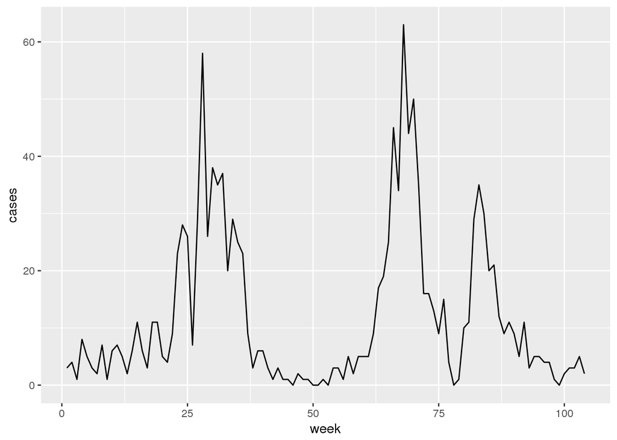

The two year window of weekly laboratory confirmed dengue cases is displayed above. There seem to be periods where there are relatively low number of dengue cases and then sudden outbreaks where the count of cases increases sharply.

# SISIR Model

## Model Description

In order to account for the fact that recovering from one serotype of dengue only grants immunity to that particular serotype and that second infections are typical in endemic countries, we model dengue transmission using an SISIR model. That is instead of assuming that a recovered patient is immune to the disease, we assume that they are thrown into another susceptible state whereby after recovering from another infection they are finally immune to dengue. This assumption is based on the research of Gibbons et al. (2007) who demonstrate that third and fourth incidences of dengue are very rare.

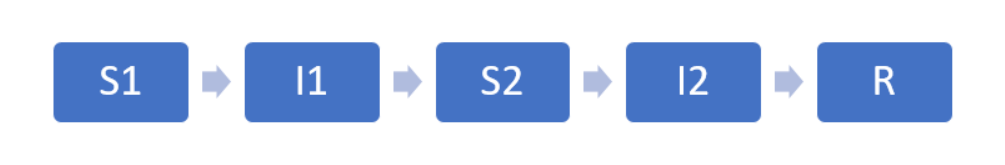

Regarding the model states, we let $S_1$ be the number of susceptible people in the population who have yet to contract dengue, $I_1$ the number of people infected with Dengue for the first time, $S_2$ the number of people who have recovered from dengue but are in risk of contracting it once again, $I_2$ the number of people infected with dengue for the second time, and lastly $R$ the number of people that have recovered from dengue twice. For the model parameters once again let $\beta$ be the contact rate, $\mu$ the rate the population increases (birth rate), $\sigma$ the rate of recovery, and $\kappa$ the reporting rate. We also introduce a new parameter $\gamma$ which represents the increased susceptibility to contracting dengue after receiving it once.

The states of our model can be represented by the following set of equations
$$\begin{align}
S_1(t) &= S_1(0) + B(t) - N_{S_1I_1}(t) \\
I_1(t) &= I_1(0) + N_{S_1I_1}(t) - N_{I_1S_2}(t) \\
S_2(t) &= S_2(0) + N_{I_1S_2}(t) - N_{S_2I_2}(t) \\
I_2(t) &= I_2(0) + N_{S_2I_2}(t) - N_{I_2R}(t) \\
R(t) &= R(0) + N_{I_2R}(t).
\end{align}$$
Again, $N_{XY}$ represents the number of people who have moved from state $X$ to state $Y$ and $B(t)$ represents number of births at week $t$, a Poisson approximation is used to model $B(t) = \text{Poisson}[\mu dt]$, and each $N_{XY}$ is modeled using a Binomial approximation with exponential transition probabilities:
$$\begin{align}
N_{S_1I_1}(t + \delta) &= N_{S_1I_1}(t) + \text{Binomial}\bigg[S_1(t), 1 - \exp\bigg\{-\beta \frac{I_1(t)+I_2(t)}{P} \delta \bigg\}\bigg] \\
N_{I_1S_2}(t + \delta) &= N_{I_1S_2}(t) + \text{Binomial}\bigg[I_1(t), 1 - \exp\bigg\{-\sigma \delta \bigg\}\bigg] \\
N_{S_2I_2}(t + \delta) &= N_{S_2I_2}(t) + \text{Binomial}\bigg[S_2(t), 1 - \exp\bigg\{-(\beta + \gamma) \frac{I_1(t)+I_2(t)}{P} \delta \bigg\}\bigg] \\
N_{I_2R}(t + \delta) &= N_{I_2R}(t) + \text{Binomial}\bigg[I_2(t), 1 - \exp\bigg\{-\sigma \delta \bigg\}\bigg] \\
\end{align}$$

where $P$ is the total population.

In addition to run our model in POMP we have 3 other parameters. $P$ for the initial population size, $S1_0$ the proportion of the initial population that belongs in the latent state $S_1(0),$ $I1_0$ the proportion of the initial population that belongs in the latent state $I_1(0).$ To keep the model relatively simple we fix the initial proportion of the population in $S_2(0)$ and $I_2(0)$ at 0. After calculating what the initial count for each latent state is besides R, we take the initial number of people in state R as $P - S_1(0) - I_1(0).$

## Implementation

```r
(L1 <- logmeanexp(sapply(pf1,logLik),se=TRUE))
```

```
##                          se
## -3.704687e+02  5.876722e-03
```

### Likelihood Maximization

After creating a POMP model using the parameter values above, we get a likelihood estimate of -370.469. Although we had scientific reasoning and intuition behind most of our parameter values, this was not true for all our parameters. This means that we can probably improve on our parameter estimates. This can be accomplished using the iterated filtering algorithm developed by Ionides et al. (2015).

```r
summary(r2$logLik,digits=5)
```

```
##    Min. 1st Qu.  Median    Mean 3rd Qu.    Max.
##  -308.6  -308.2  -308.1  -308.1  -308.0  -307.9
```

After performing local maximization we see that we have increased the likelihood by a little over 60.

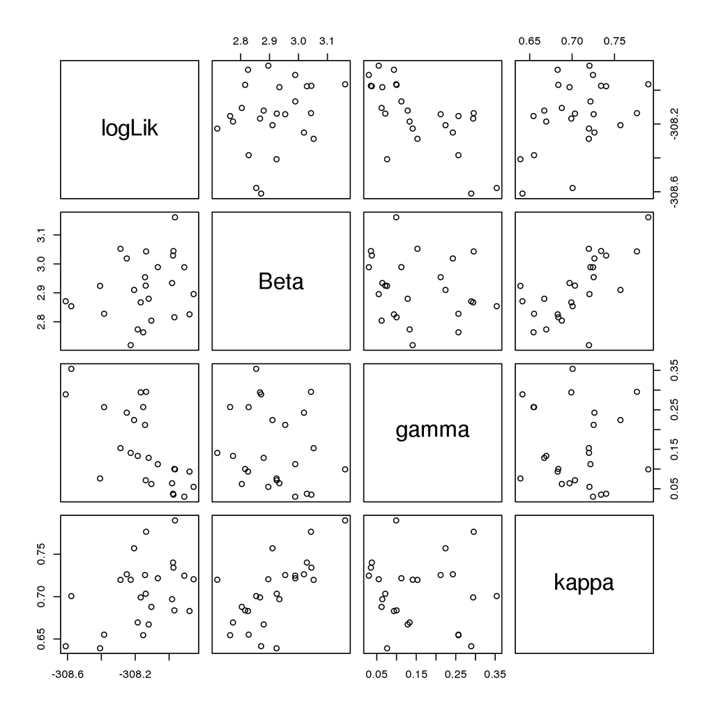

```r
pairs(~logLik+Beta+gamma+kappa,data=r2)
```

The important thing to note from the plot is that the values of $\kappa$ are very large (all over 0.6). In reality, of course the reporting rate is nowhere near as large as the MLE value here. This also calls into question our other MLE estimates as well. Perhaps if we do a global likelihood maximization rather than local, we can get better MLE estimates.

### Diagnostics

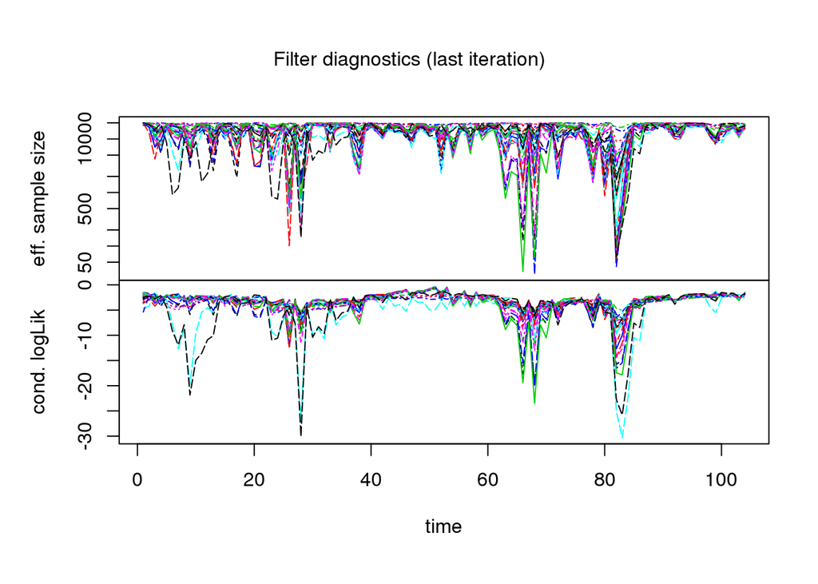

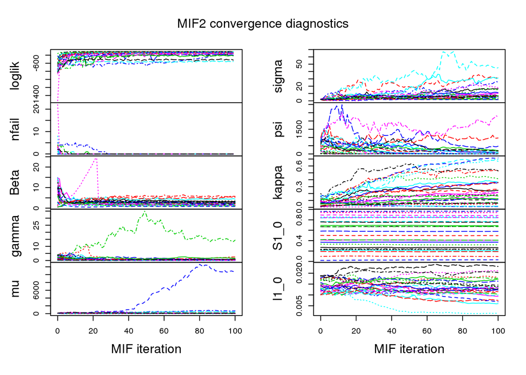

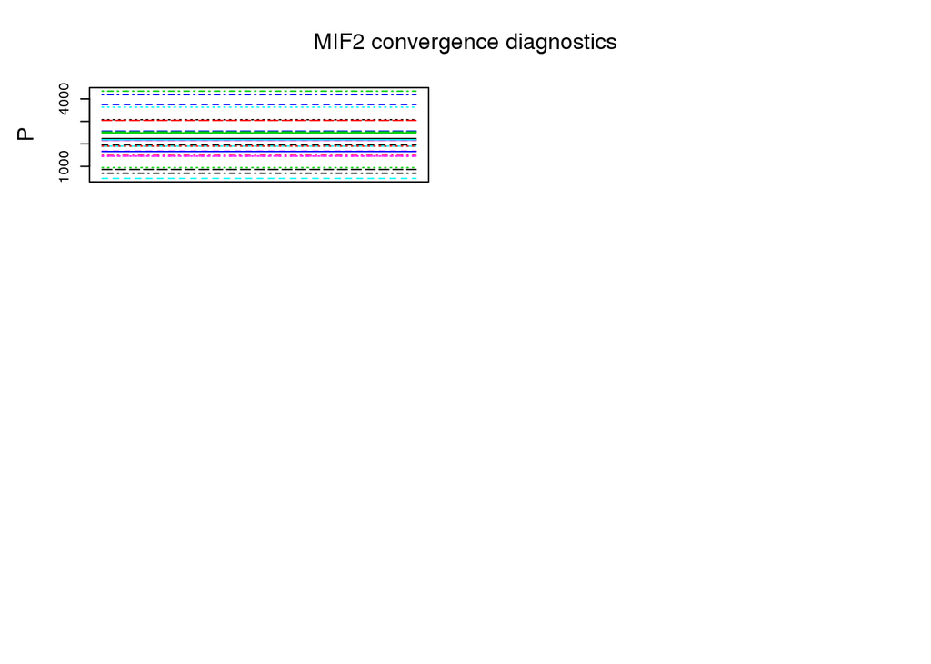

The only major concern that the diagnostic plots show is that the population parameter and the initial value parameters have either converged to all different values or do not seemed to have converged. This is probably due to the fact that these are the values for which we had the least intuition. Further, the random walk standard deviation had to very small for the initial value parameters as larger random walk standard deviations would lead to the particle filter failing due to an infinite likelihood. However, these parameters are not the parameters of interest for analysis, so we proceed with caution.